# Tugas Tambahan Analisis Runtun Waktu

Tubagus Langlang Purwasasmita

1/23/2021

## Loading Data and Descriptive

```r
samsung.closed <- getSymbols('KRX', auto.assign = F)$KRX.Close %>% na.omit()
```

[output not shown]

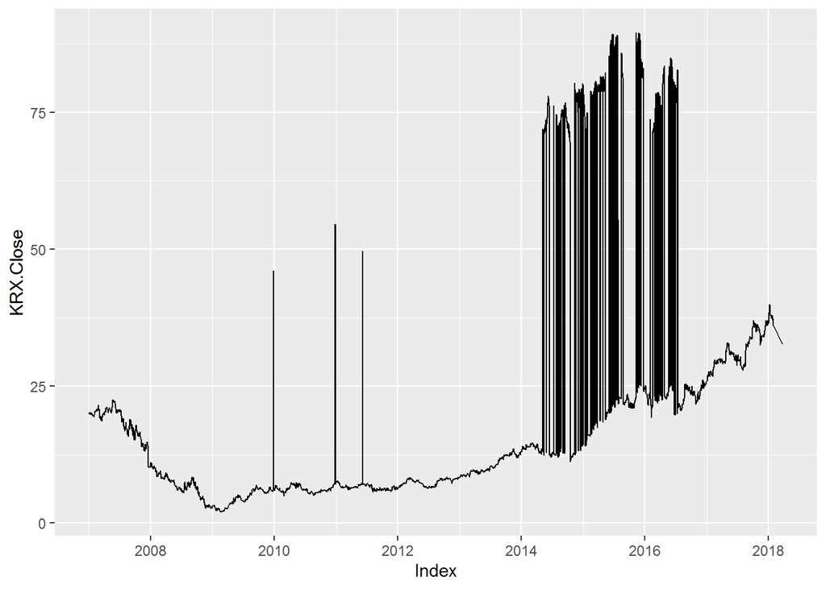

```r
samsung.closed %>% na.omit() %>% autoplot()
```

Dari plot diatas, dapat dilihat terdapat anomali pada beberapa periode. Seperti periode 2014 hingga 2016 yang memiliki nilai saham closed nya sangat tinggi dibanding yang lainnya. Ini akan menyulitkan forecasting tentunya (bagi saya), karena volatilitas yang cukup tinggi. Oleh karena itu, saya akan menggantinya dengan cara interpolasi

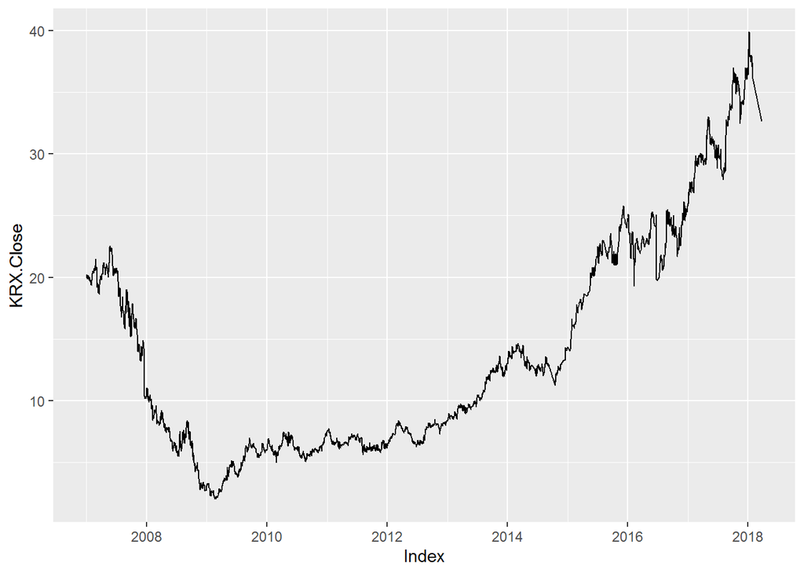

```r
samsung.closed <- replace(samsung.closed$KRX.Close, samsung.closed$KRX.Close > 45, NA) %>% na_interpolation()
samsung.closed %>% autoplot()
```

Interpolasi yang dilakukan berupa linier untuk data time series

## Mengecek Stasioneritas

### Menggunakan Plot

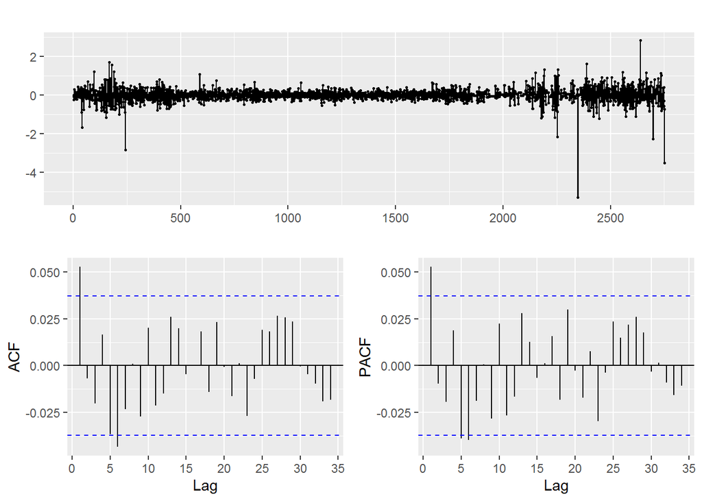

```r
ggtsdisplay(samsung.closed %>% diff())
```

### Menggunakan Uji ADF

```r
tseries::adf.test(samsung.closed %>% diff() %>% na.omit())
```

```
##
##  Augmented Dickey-Fuller Test
##
## data:  samsung.closed %>% diff() %>% na.omit()
## Dickey-Fuller = -13.688, Lag order = 14, p-value = 0.01
## alternative hypothesis: stationary
```

Dengan adf.test, dapat dilihat p-value yang kurang dari 5% mengindikasikan **Tolak H0** yang berarti data sudah stasioner.

Berdasarkan plot sebelumnya, yaitu ACF dan PACF. Maka didapatkan beberapa kandidat model :

ARIMA(1,1,0) ARIMA(0,1,1) ARIMA(1,1,1) ARIMA(5,1,0) ARIMA(0,1,5) ARIMA(5,1,5)

## Penentuan Model

```r
# Model uji coba untuk mencari model dengan AIC terbaik
model110 <- samsung.closed %>% Arima(c(1,1,0))
model011 <- samsung.closed %>% Arima(c(0,1,1))
model111 <- samsung.closed %>% Arima(c(1,1,1))
model510 <- samsung.closed %>% Arima(c(5,1,0))
model015 <- samsung.closed %>% Arima(c(0,1,5))
model515 <- samsung.closed %>% Arima(c(5,1,5))

# Auto arima yang diterapkan ke dalam model
auto.model <- auto.arima(samsung.closed)

model <- list(
  model110, model011, model111, model510, model015, model515
)

data.frame(
  aic = purrr::map_dbl(model,function(x){x$aic}),
  aicc = purrr::map_dbl(model,function(x){x$aicc}),
  bic = purrr::map_dbl(model,function(x){x$bic}),
  loglik = purrr::map_dbl(model,function(x){x$loglik}),
  row.names = c(
    'model110', 'model011', 'model111', 'model510', 'model015', 'model515'
  )
) %>% arrange(loglik)
```

```
##               aic     aicc      bic    loglik
## model110 1386.270 1386.274 1398.109 -691.1348
## model011 1386.160 1386.165 1398.000 -691.0802
## model111 1388.141 1388.150 1405.900 -691.0706
## model015 1389.034 1389.065 1424.552 -688.5170
## model510 1387.750 1387.781 1423.269 -687.8752
## model515 1373.127 1373.223 1438.244 -675.5634
```

```r
auto.model %>% summary()
```

```
## Series: samsung.closed
## ARIMA(5,2,0)
##
## Coefficients:
##           ar1      ar2      ar3      ar4      ar5
##       -0.7642  -0.6075  -0.4582  -0.2672  -0.1412
## s.e.   0.0192   0.0237   0.0251   0.0238   0.0192
##
## sigma^2 estimated as 0.1136:  log likelihood=-909.38
## AIC=1830.76   AICc=1830.79   BIC=1866.28
##
## Training set error measures:
##                        ME      RMSE       MAE          MPE     MAPE     MASE
## Training set -0.001540316 0.3366279 0.2079929 -0.005418571 1.862347 1.121657
##                     ACF1
## Training set -0.01947631
```

Dapat dilihat, model Arima 5,1,5 mendapatkan AIC yang relatif kecil dibanding lainnya (Meskipun BIC dan loglikelihood yang belum terlalu kecil). Disusul oleh Arima 0,1,1

Di sisi lain, dengan kriteria BIC, model Arima 0,1,1 mendapat BIC terkecil, disusul oleh Arima 1,1,0

Dan pada kriteria Loglikelihood, model Arima 1,1,0 lah yang terkecil, disusul oleh 0,1,1

Di sisi lain, dengan `auto.arima`, kita mendapatkan model Arima 5,2,0 dengan AIC (1830.76) dan AICC (1830.79). Ini juga akan menjadi kandidat

## Melihat persebaran residual kuadrat

### Kandidat pertama (ARIMA 5,1,5)

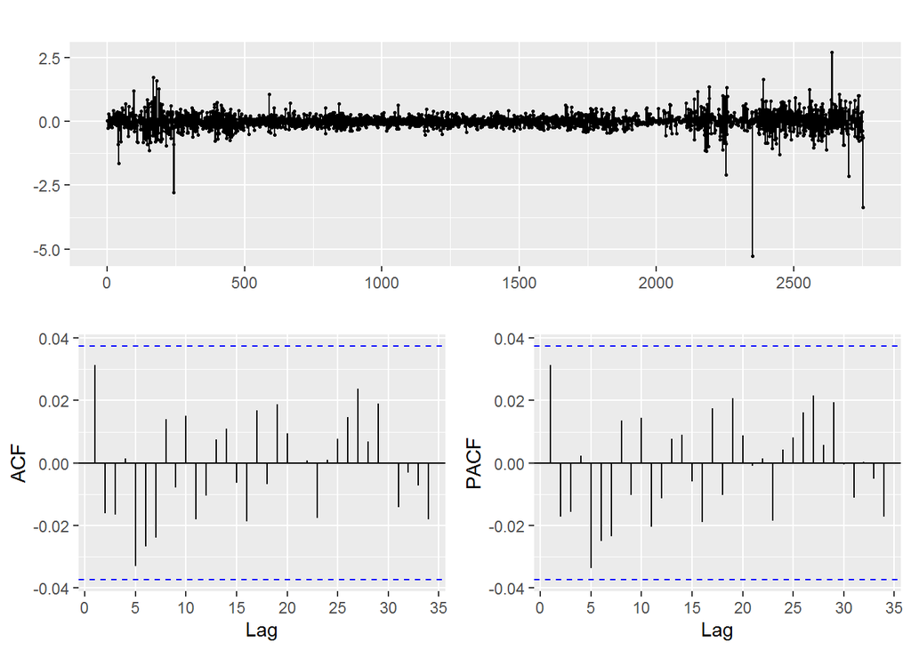

```r
rsd <- model515$residuals
rsd2 <- rsd^2

rsd %>% ggtsdisplay()
```

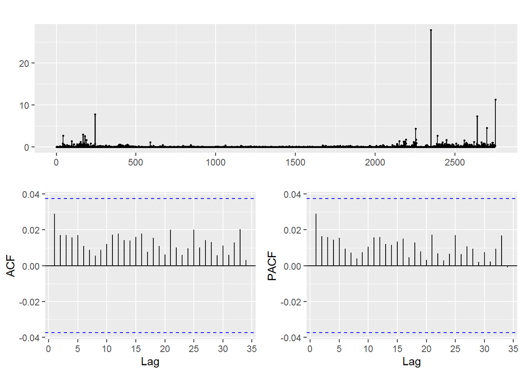

```r
rsd2 %>% ggtsdisplay()
```

Pada semua lag, sudah tidak terlalu signifikan korelasinya residual kuadrat nya. Maka dari itu, saya rasa model ini tidak perlu melanjutkan ke model GARCH

### Kandidat 2 (ARIMA(0,1,1))

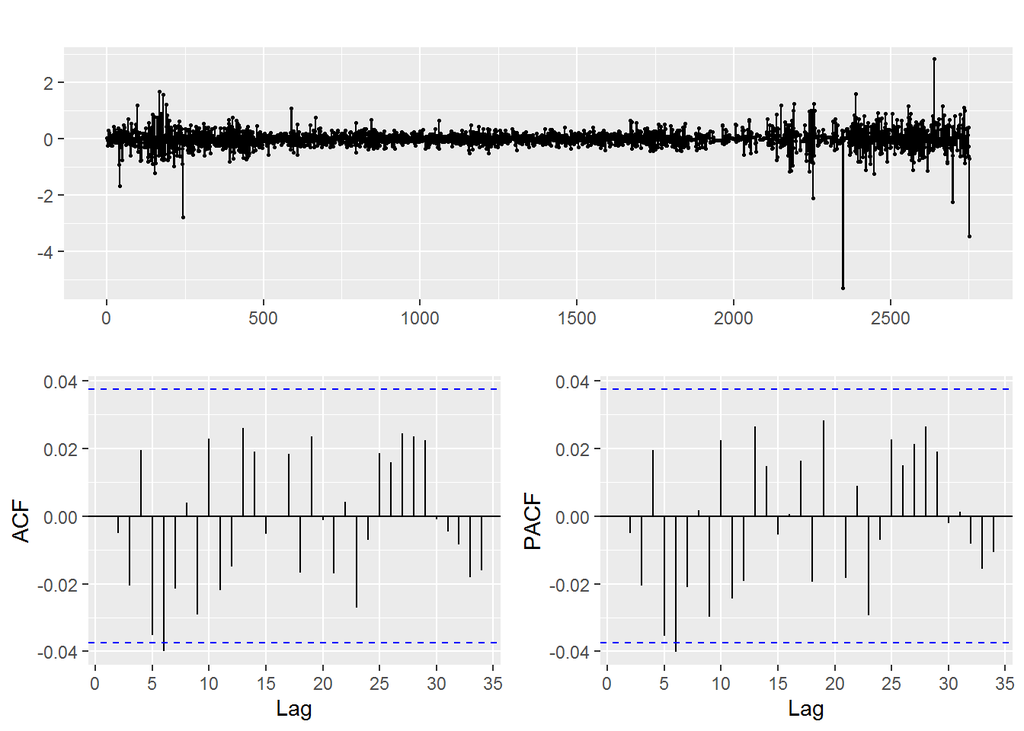

```r
rsd <- model011$residuals
rsd2 <- rsd^2

rsd %>% ggtsdisplay()
```

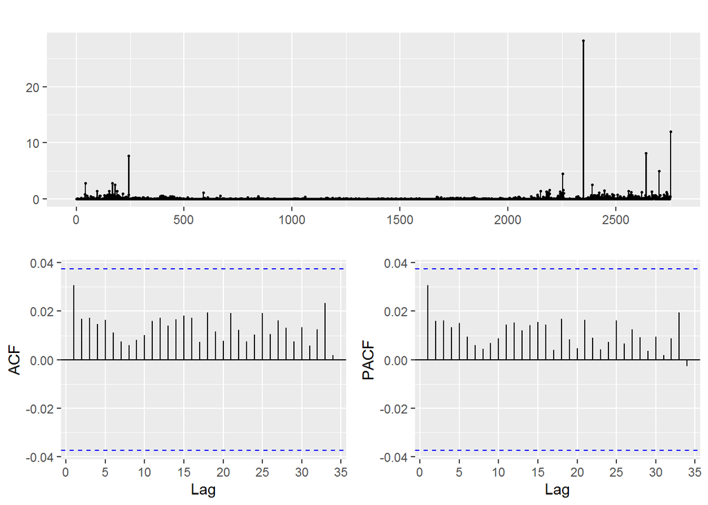

```r
rsd2 %>% ggtsdisplay()
```

Begitu pula dengan model ARIMA(0,1,1) yang sudah tidak signifikan lagi pada korelasi residual kuadratnya.

### Kandidat 3 (Auto Arima)

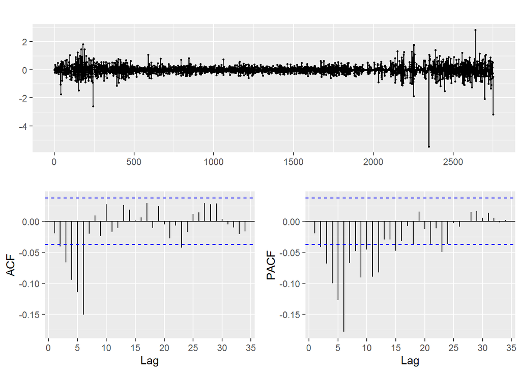

```r
rsd <- auto.model$residuals
rsd2 <- rsd^2

rsd %>% ggtsdisplay()
```

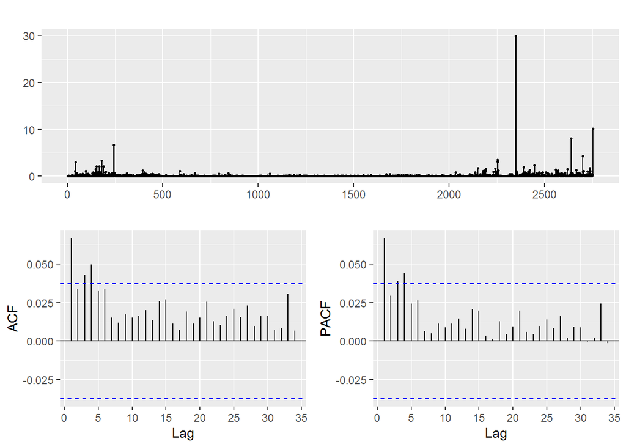

```r
rsd2 %>% ggtsdisplay()
```

Pada ARIMA(5,2,0), residual kuadratnya masih berkorelasi pada beberapa lag. Hal ini dapat mengindikasikan model GARCH untuk model lanjutan.

GARCH(1,0) GARCH(1,1) GARCH(0,1) GARCH(3,0) GARCH(3,3) GARCH(0,3) GARCH(4,0) GARCH(4,4) GARCH(0,4)

## Pembuatan Model GARCH

```r
garch_model = list()
# Pembuatan fungsi agar mudah mencari model GARCH berdasarkan kriterianya

func <- function(order){
  # Spesifikasi GARCH berdasarkan parameter order
  ugs <- ugarchspec(
    variance.model = list(
      model = 'sGARCH',
      garchOrder = order
    ),
    mean.model = list(
      armaOrder = c(5,2,1)
    )
  )

  # Fitting spesfikasi terhadap data
  ugf <- ugarchfit(ugs, data = samsung.closed)

  # Nama model (berdasarkan order)
  model_name <- paste("GARCH ", order[1], order[2], sep = "")
  # Kriteria informasi yang akan diberikan
  ic <- infocriteria(ugf)

  # Menambahkan model ke list
  garch_model[[model_name]] <- ugf

  list(
    model.name = model_name,
    Akaike = ic[1],
    Bayes = ic[2],
    Shibata = ic[3],
    Hannan.Quinn = ic[4]
  )
}

order <- list(
  c(1,0), c(1,1), c(0,1), c(3,0), c(0,3), c(3,3), c(4,0), c(0,4), c(4,4)
)

sum_ic <- purrr::map_df(order, func)
sum_ic %>% arrange(Akaike)
```

```
## # A tibble: 9 x 5
##   model.name Akaike Bayes Shibata Hannan.Quinn
##   <chr>       <dbl> <dbl>   <dbl>        <dbl>
## 1 GARCH 44   0.0684 0.105  0.0684       0.0816
## 2 GARCH 33   0.0909 0.123  0.0909       0.103
## 3 GARCH 11   0.0935 0.117  0.0935       0.102
## 4 GARCH 40   0.115  0.143  0.115        0.125
## 5 GARCH 30   0.130  0.156  0.130        0.139
## 6 GARCH 10   0.288  0.309  0.288        0.296
## 7 GARCH 03   0.493  0.519  0.493        0.502
## 8 GARCH 04   0.493  0.521  0.493        0.503
## 9 GARCH 01   0.507  0.529  0.507        0.515
```

Dapat dilihat, **GARCH(4,4)** memiliki Akaike Information Criteria relatif rendah, dibanding dengan model lain. Begitu pula dengan Kriteria Bayes, Shibata, dan Hannan.Quinn.

Berikut ini adalah plot ACF dan PACF dari residual hasil fitting model model yang sudah dipilih

Selanjutnya, saya akan memperlihatkan conditional varians dari model yang dipilih vs residual yang dikuadratkan

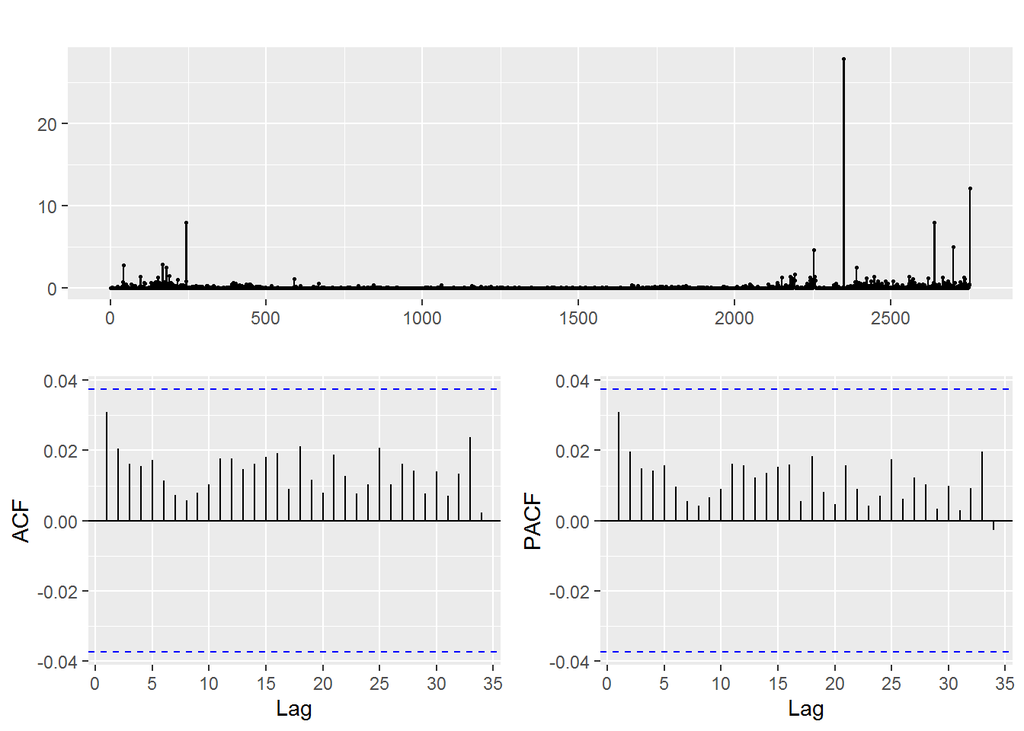

```r
ugf <- ugarchfit(
  ugarchspec(
    variance.model = list(
      model = 'sGARCH',
      garchOrder = c(4,4)
    ),
    mean.model = list(
      armaOrder = c(5,2,1)
    )
  ),
  samsung.closed
)

ugf@fit$residuals^2 %>% ggtsdisplay()
```

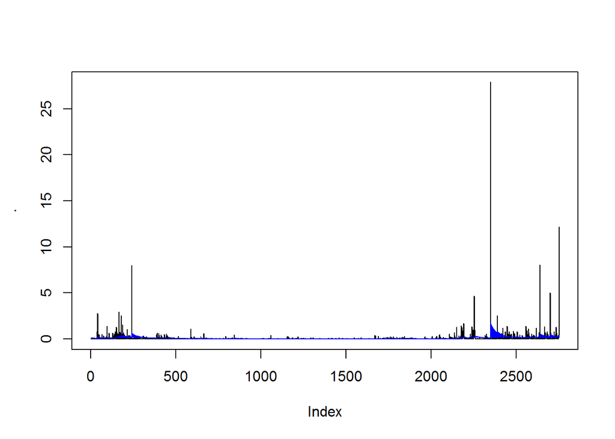

```r
ugf@fit$residuals^2 %>% plot(type = 'l')
ugf@fit$var %>% lines(col = 'blue')
```

Dapat dilihat pada plot pertama, tidak terdapat korelasi yang signifikan lagi untuk masing-masing lag baik dari PACF dan ACF.

Dapat dilihat juga pada plot kedua, conditional varians (Biru) nya mengikuti residual square (Hitam) nya.

Berikut adalah koefisien yang digunakan

```r
ugf@fit$coef
```

```
##            mu           ar1           ar2           ar3           ar4
##  2.001514e+01  5.884161e-01 -4.289569e-01  8.213755e-01  1.960637e-03
##           ar5           ma1           ma2         omega        alpha1
##  1.619423e-02  4.220541e-01  8.007984e-01  1.952976e-04  5.701793e-02
##        alpha2        alpha3        alpha4         beta1         beta2
##  3.127057e-03  1.811360e-07  4.935611e-08  6.261233e-07  1.665030e-02
##         beta3         beta4
##  2.155304e-02  9.006508e-01
```

## Forecasting

[figure not shown]

```
plot(ugfore)
```

[figure not shown]

```r
ugfore <- ugarchforecast(ugf, n.ahead = 10)

ug_var_t <- c(tail(ugf@fit$var,20),rep(NA,10))  # gets the last 20 observations
ug_res2_t <- c(tail(ugf@fit$residuals^2,20),rep(NA,10))  # gets the last 20 observations
ug_f <- c(rep(NA,20),ugfore@forecast$sigmaFor)

plot(ug_res2_t, type = "l", col = 'red', main = 'Residual^2 vs Conditional Varians')
lines(ug_f, col = "orange")
lines(ug_var_t, col = "green")
```